# Imputacja a klasyfikacja

1. Wstęp
2. Opis metodologii
3. Esploracyjna analiza zbioru
4. Metody imputacji ad-hoc, modele i miary
   1. Usunięcie wierszy zawierających braki danych
   2. Usunięcie kolumn zawierających braki danych
   3. Zastąpienie brakujących danych dominantami poszczególnych kolumn
   4. Zastąpienie brakujących danych wartościami wylosowanymi z poszczególnych kolumn (random uniform)
   5. Zastąpienie brakujących danych wartościami wylosowanymi z poszczególnych kolumn (random stratified)
5. Podsumowanie
6. Ogólne wnioski

## 1. Wstęp

Badanie wpływu podstawowych metod imputacji brakujących danych na wydajność metod klasyfikacji przeprowadzono na przykładzie zestawu danych cylinder-bands (https://www.openml.org/d/6332) oraz **metody drzew decyzyjnych**.

Raport powstał w oparciu o otrzymane wyniki i zawiera podstawową eksplorację danych, opis metodologii oraz podsumowanie uzyskanych rezultatów.

```r
set.seed(123)
```

Dwie spośród poniższych technik imputacji oparte są na losowości, dlatego istotne jest ustawienie ziarna, gdyż zabieg ten zagwarantuje reprodukowalność otrzymanych rezultatów.

## 2. Opis metodologii

**Klasyfikację rpart (drzew decyzyjnych)** wykorzystuje się do wyznaczania przynależności przypadków lub obiektów do klas jakościowej zmiennej zależnej na podstawie pomiarów jednej lub więcej zmiennych objaśniających. Oparta jest na podziale próby statystycznej na klasy obserwacji o podobnych właściwościach.

Mamy zbiór danych składający się ze zbioru informatywnego (atrybutów, cech, zmiennych objaśniających) i klas (odpowiedzi ang. label). Na podstawie próby uczącej chcemy podać regułę klasyfikacyjną, tzn. dla dowolnej nowej obserwacji umieć podać jego klasę.  
Ważne, aby stworzony model w oparciu o doświadczenie dawał coraz lepsze rezultaty względem pewnej miary, czyli żeby charakteryzował się zdolnością generalizacji. W tym celu stosujemy podział na zbiór walidacyjny (treningowy) i testowy. Dzięki niemu, jesteśmy w stanie ocenić, czy model nie dopasował się nadmiernie do danych uczących (nie przeuczył się) oraz czy daje dobre wyniki dla nowych danych.

Większość algorytmów uczenia maszynowego nie radzi sobie z brakami danych. Aby umożliwić działanie algorytmu na zbiorze należy usunąć rekordy zawierające braki lub imputować brakujące wartości. Na potrzeby zadania wykonanych zostało 5 modyfikacji rozważanego zbioru, tj.:

- usunięcie rekordów zawierających braki,
- usunięcie zmiennych objaśniających, w których występują braki,
- zastąpienie brakujących danych dominantami poszczególnych cech,
- zastąpienie brakujących danych wartościami wylosowanymi z poszczególnych kolumn (random uniform),
- zastąpienie brakujących danych wartościami wylosowanymi z poszczególnych kolumn (random stratified)

W celu uniknięcia wycieku danych (ang. leakage), techniki imputacji zostały wykonane po usunięciu ze zbioru zmiennych odpowiedzi. Dzięki temu mamy pewność, że model nie korzysta z informacji o zmiennej, którą ma przewidywać.

**Uwaga!** W rozważanym zbiorze klasą jest zmienna **band type**, we wszystkich poniższych analizach stosunek liczności zbiorów walidacyjnego i testowego wynosi 4:1.

## 3. Eksploracyjna analiza zbioru (EDA)

**Jak duży jest zbiór - jaka jest skala problemu?**

```r
dim(data)
```

```
## [1] 540  40
```

Analizowany zbiór danych składa się z 40 atrybutów i 540 obserwacji.

Sprawdzenie ilości możliwych odpowiedzi oraz liczności poszczególnych klas.

```r
levels(data$band_type)
```

```
## [1] "band"   "noband"
```

```r
percentage <- prop.table(table(data$band_type)) * 100
cbind(freq=table(data$band_type), percentage=percentage)
```

```
##        freq percentage
## band    228   42.22222
## noband  312   57.77778
```

Na klasę składają się dwie kategorie - zbiór odpowiedzi jest dyskretny (skończony), zatem w dalszej części rozważań nie możemy brać pod uwagę algorytmu regresji, tylko klasyfikacji.  
Dane są zbilansowane- nie ma dużej różnicy pomiędzy licznościami klas negatywnej i pozytywnej, dlatego też w poniższych rozważaniach jako jedną z miar predykcji będziemy uważać Accuracy (w takiej sytuacji nie ma potrzeby obliczania precision i recall).

**Typy atrybutów**

```r
sapply(data, class)
```

```
##           timestamp     cylinder_number            customer
##           "integer"            "factor"            "factor"
##          job_number      grain_screened           ink_color
##           "integer"            "factor"            "factor"
##    proof_on_ctd_ink           blade_mfg   cylinder_division
##            "factor"            "factor"            "factor"
##          paper_type            ink_type        direct_steam
##            "factor"            "factor"            "factor"
##        solvent_type    type_on_cylinder          press_type
##            "factor"            "factor"            "factor"
##               press         unit_number       cylinder_size
##           "integer"           "integer"            "factor"
## paper_mill_location        plating_tank           proof_cut
##            "factor"            "factor"            "factor"
##           viscosity             caliper     ink_temperature
##            "factor"            "factor"            "factor"
##            humifity           roughness      blade_pressure
##            "factor"            "factor"            "factor"
##         varnish_pct         press_speed             ink_pct
##            "factor"            "factor"            "factor"
##         solvent_pct         ESA_Voltage        ESA_Amperage
##            "factor"            "factor"            "factor"
##                 wax            hardener    roller_durometer
##            "factor"            "factor"            "factor"
##     current_density   anode_space_ratio      chrome_content
##            "factor"            "factor"            "factor"
##           band_type
##            "factor"
```

Włącznie z klasą w zbiorze jest 20 atrybutów numerycznych i 20 nominalnych. Ponadto, 4 są typu integer a 36 factor.

**Podsumowanie statystyczne**

```r
summary(data)
```

```
##    timestamp        cylinder_number    customer     job_number
##  Min.   :19900330   m254   :  5     kmart  : 67   Min.   :23040
##  1st Qu.:19900909   x129   :  5     modmat : 64   1st Qu.:34585
##  Median :19910117   f601   :  4     target : 41   Median :36062
##  Mean   :19907801   r15    :  4     tvguide: 38   Mean   :37288
##  3rd Qu.:19910604   r6     :  4     wards  : 33   3rd Qu.:37528
##  Max.   :19941010   f670   :  3     toysrus: 26   Max.   :88231
##                     (Other):515     (Other):271
##  grain_screened ink_color proof_on_ctd_ink    blade_mfg
##  ?  : 49        key:540   ?  : 57          ?       : 60
##  no :281                  no : 22          benton  :479
##  yes:210                  yes:461          uddeholm:  1
##
##
##
##
##  cylinder_division    paper_type      ink_type   direct_steam solvent_type
##  gallatin:540      coated  :223   coated  :291   ?  : 25      ?     : 55
##                    super   : 23   cover   : 18   no :513      line  :468
##                    uncoated:294   uncoated:231   yes:  2      naptha:  2
##                                                               xylol : 15
##
##
##
##  type_on_cylinder     press_type      press        unit_number
##  ?  : 18          albert70 : 78   Min.   :802.0   Min.   : 1.000
##  no :136          motter70 : 48   1st Qu.:815.0   1st Qu.: 2.000
##  yes:386          motter94 :238   Median :816.0   Median : 2.000
##                   woodhoe70:176   Mean   :817.7   Mean   : 4.878
##                                   3rd Qu.:824.0   3rd Qu.: 9.000
##                                   Max.   :828.0   Max.   :10.000
##
##  cylinder_size   paper_mill_location plating_tank   proof_cut
##  ?      :  3   ?           :156      ?   : 18     40     :111
##  catalog:178   canadian    :159      1910:332     50     : 76
##  spiegel: 60   mideuropean : 15      1911:190     45     : 58
##  tabloid:299   northus     :189                   ?      : 55
##                scandanavian: 13                   30     : 34
##                southus     :  8                   35     : 34
##                                                   (Other):172
```

[output cut: 17 more lines]

```
##  0      :320   ?  : 55      2.5    :251   1      :187   30     :130
##  ?      : 57   0  :480      3      : 84   0.8    : 48   40     :125
##  2      : 33   0.5:  1      2      : 31   0.9    : 47   33     : 66
##  4      : 29   4  :  3      1.5    : 20   0.7    : 32   35     : 59
##  1      : 24   6  :  1      2.7    : 16   0.6    : 31   ?      : 55
##  3      : 23                2.4    : 12   1.5    : 30   34     : 53
##  (Other): 54                (Other):126   (Other):165   (Other): 52
##  current_density anode_space_ratio chrome_content  band_type
##  40     :431     100    :124       ?  :  3        band  :228
##  35     : 64     106.45 : 42       100:510        noband:312
##  33     : 21     103.125: 35       90 : 17
##  ?      :  7     103.22 : 33       95 : 10
##  30     :  6     106.25 : 17
##  45     :  6     103.3  : 16
##  (Other):  5     (Other):273
```

Braki danych oznaczone są jako ‘?’. W celu ułatwienia dalszej eksploracji należy oznaczyć je jako NA.

Poniższe kolumny mogą być uznane za nieinformatywne ze względu na liczbę poziomów:

1. cylinder_number - zmienna jest identyfikatorem i nie powinna być wykorzystywania przy modelowaniu,
2. ink_color - wszystkie instancje mają taką samą wartość atrybutu,
3. cylinder_division - j.w.
4. blade_mfg - większość instancji ma taką samą wartość atrybutu / brak danych,
5. direct_steam - j.w.
6. ESA_Amperage - j.w.

```r
data[data == "?"] <- NA
data <- data[, -c(2,6,8,9,12,23)]
```

Większość modeli uczenia maszynowego nie potrafi wnioskować na podstawie napisów. Dlatego, tego typu zmienne kategoryczne należy zakodować. Label encoding podaje numeryczne odpowiedniki różnych klas. Problemem, który może pojawić się przy okazji wykorzystania tej metody jest fakt, że algorytm może uważać niezwiązane ze sobą klasy za uporządkowane (innymi słowy będzie dopatrywał się relacji między nimi). Ryzyko wystąpienia tego typu komplikacji zminimalizujemy konwertując otrzymane w ten sposób zmienne numeryczne na factory. Dzięki temu algorytm będzie je interpretował jako niezależne kategorie i nie będzie szukał dla nich interpretacji relacyjnej.

**Wizualizacja zbioru danych**

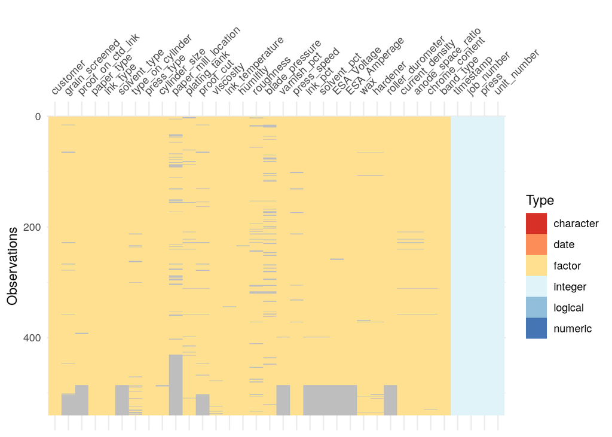

```r
# df - zbiór danych po zakodowaniu
vis_dat(df, palette = 'cb_safe')
```

Większość atrybutów została wczytana jako zmienne typu factor. Z wcześniejszych rozważań wiadomo jednak, że blisko połowa zmiennych objaśniających jest typu numerycznego. Należy więc przekonwertować te dane na odpowiadające im typy (integer/numeric).

**Dane po konwersji**

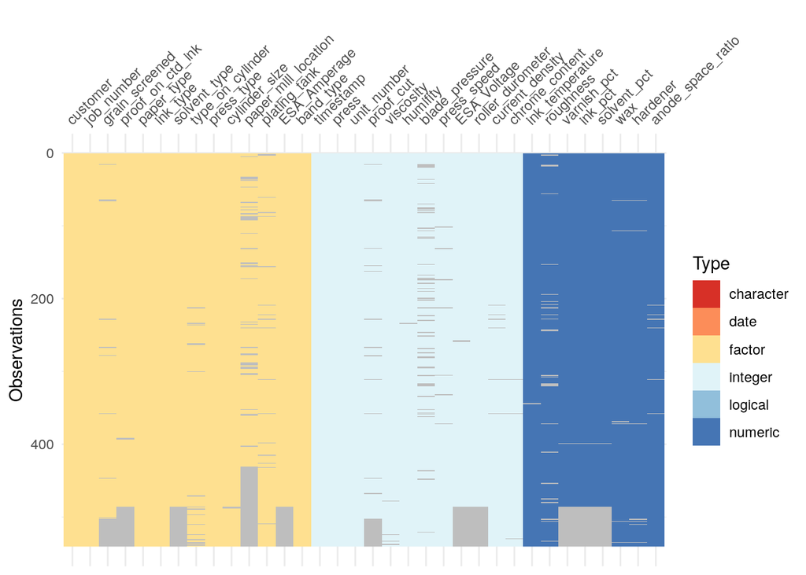

```r
vis_dat(df, palette = 'cb_safe')
```

**Braki danych**

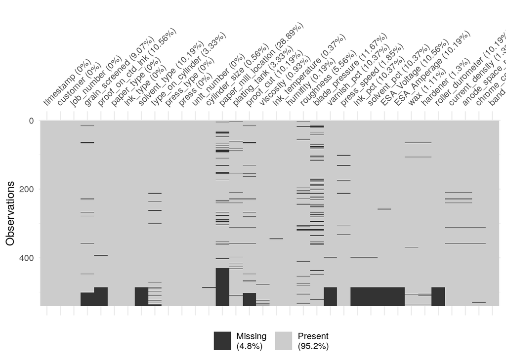

```r
vis_miss(df)
```

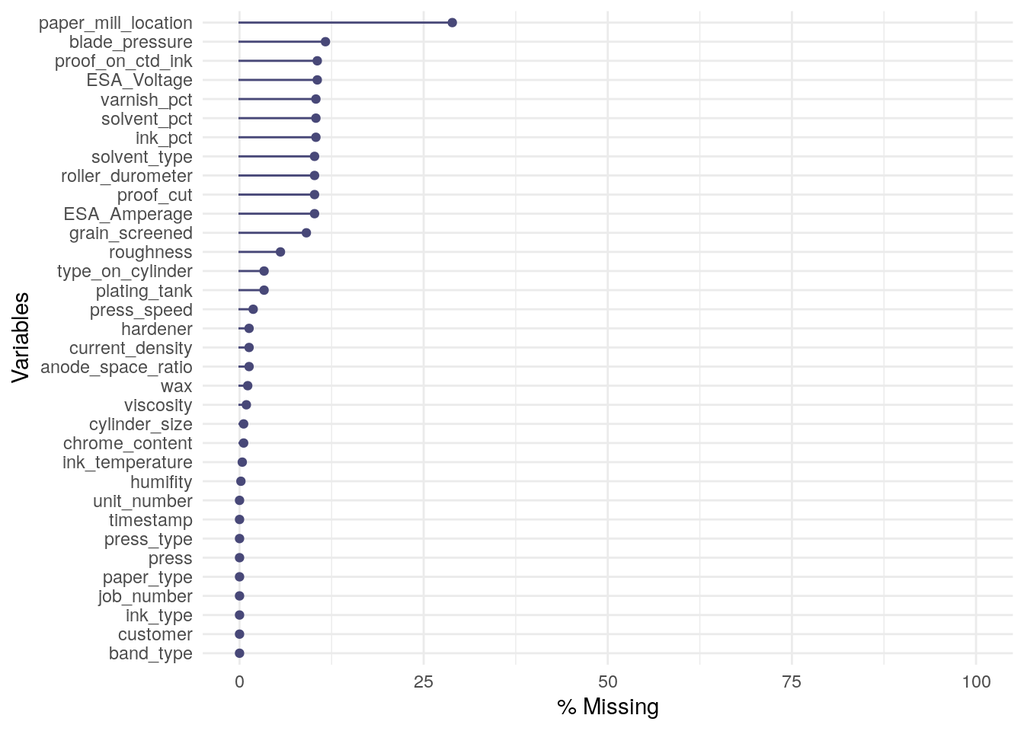

```r
gg_miss_var(df,
            show_pct = TRUE) +
  ylim(0, 100)
```

W przypadku wielu zmiennych objaśniających, brakuje pojedynczych instancji a nie całych agregatów danych. Dlatego też istnieje ryzyko, że usunięcie kolumn/wierszy z brakami może spowodować utratę wielu informacji.

**Zależności pomiędzy brakami danych**  
Licznośni braków dla kombinacji 5 zmiennych o największych ilościach brakujących obserwacji.

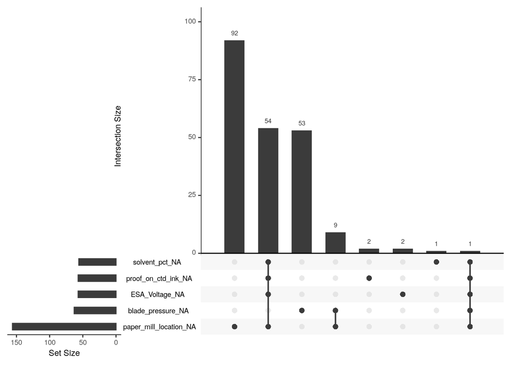

```r
gg_miss_upset(df)
```

## 4. Metody imputacji ad-hoc, modele i miary

### 4.1. Usunięcie wierszy zawierających braki danych

```r
dim(df_wo_na_rows)
```

```
## [1] 288  34
```

```r
dim(df)
```

```
## [1] 540  34
```

Po usunięciu wierszy z brakami danych utracono blisko 47% obserwacji!

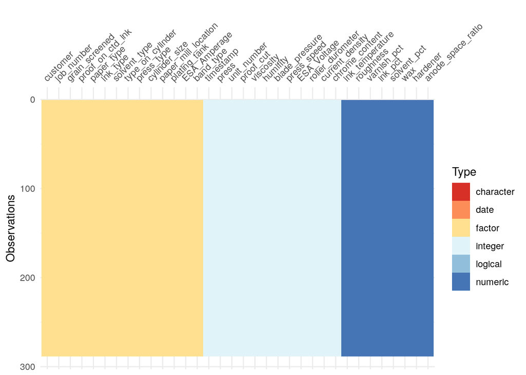

```r
# Brak braków
vis_dat(df_wo_na_rows, palette = 'cb_safe')
```

#### 4.1.1. Predykcja klasy - macierz błędu

Zakładamy, że aby móc wykonać podział, w węźle musi znajdować się co najmniej 10 obserwacji. Parametr przycinania ustawiamy na 0.1.  
**Drzewo decyzyjne**

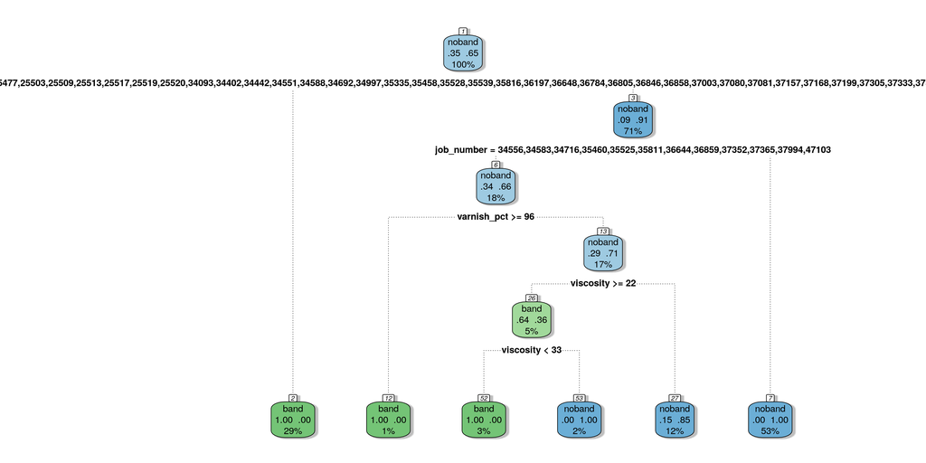

```r
tree_classifier <- rpart(band_type~., data=df_train)
fancyRpartPlot(tree_classifier_parameter_change, caption = NULL, cex = 1.2)
```

Na podstawie struktury podziałów w drzewie, można stwierdzić, że faktycznie algorytm traktuje zakodowane atrybuty jako oddzielne kategorie i nie interpretuje ich w sposób relacyjny.

Rodzaje obserwacji:

- TP - True Positive - obserwacje poprawnie zaklasyfikowane do klasy pozytywnej
- TN - True Negative - obserwacje poprawnie zaklasyfikowane do klasy negatywnej
- FP - False Positive - obserwacje niepoprawnie zaklasyfikowane do klasy pozytywnej
- FN - False Negative - obserwacje niepoprawnie zaklasyfikowane do klasy negatywnej

**Macierz błędu** (confusion matrix)

```r
table('Reference'= df_test$band_type, 'Prediction' = tree_classifier_test_prediction_class)
```

```
##          Prediction
## Reference PRED_BAND PRED_NOBAND
##    band          14          10
##    noband         8          26
```

W przypadku powyższej macierzy warto zwrócić uwagę na liczność próbki testowej. Składa się ona z zaledwie 58 obserwacji. Dla tak małej liczności próbki testowej trudno w sposób jednoznaczny określić, czy algorytm charakteryzuje się satysfakcjonującą zdolnością do generalizacji, czy też nie.

**Dokładność (accuracy)**  
Miara ta określa jaki odsetek wszystkich obserwacji został poprawnie zaklasyfikowany. Obliczana jest na podstawie danych liczbowych, wyekstrahowanych z powyższej macierzy.

```r
accuracy <- (conf.val['TP']+conf.val['TN'])/sum(conf.val)
accuracy
```

```
##        TP
## 0.6896552
```

#### 4.1.2. Predykcja prawdopodobieństwa - krzywa ROCR

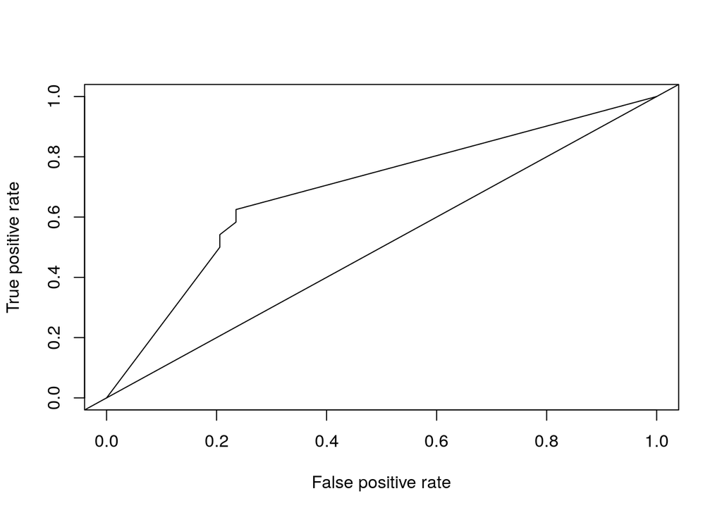

```r
# Krzywa ROCR - im bardziej stroma, tym lepszy model
plot(roc.perf)
abline(a=0, b= 1)
```

**Miara AUC**

```r
# Jest to pole pod krzywą ROCR. Im bliższe wartości 1 tym model jest lepszy
auc.perf <- performance(pred, measure = "auc")
auc.perf@y.values
```

```
## [[1]]
## [1] 0.6893382
```

#### 4.1.3. Kroswalidacja

**Porównanie błędów z kroswalidacji**

```r
rr$score(msr("classif.acc"))
```

```
##              task       task_id               learner    learner_id
##  1: <TaskClassif> df_wo_na_rows <LearnerClassifRpart> classif.rpart
##  2: <TaskClassif> df_wo_na_rows <LearnerClassifRpart> classif.rpart
##  3: <TaskClassif> df_wo_na_rows <LearnerClassifRpart> classif.rpart
##  4: <TaskClassif> df_wo_na_rows <LearnerClassifRpart> classif.rpart
##  5: <TaskClassif> df_wo_na_rows <LearnerClassifRpart> classif.rpart
##  6: <TaskClassif> df_wo_na_rows <LearnerClassifRpart> classif.rpart
##  7: <TaskClassif> df_wo_na_rows <LearnerClassifRpart> classif.rpart
##  8: <TaskClassif> df_wo_na_rows <LearnerClassifRpart> classif.rpart
##  9: <TaskClassif> df_wo_na_rows <LearnerClassifRpart> classif.rpart
## 10: <TaskClassif> df_wo_na_rows <LearnerClassifRpart> classif.rpart
##         resampling resampling_id iteration prediction classif.acc
##  1: <ResamplingCV>            cv         1     <list>   0.7586207
##  2: <ResamplingCV>            cv         2     <list>   0.7931034
##  3: <ResamplingCV>            cv         3     <list>   0.7241379
##  4: <ResamplingCV>            cv         4     <list>   0.7931034
##  5: <ResamplingCV>            cv         5     <list>   0.6551724
##  6: <ResamplingCV>            cv         6     <list>   0.8275862
##  7: <ResamplingCV>            cv         7     <list>   0.7241379
##  8: <ResamplingCV>            cv         8     <list>   0.7241379
##  9: <ResamplingCV>            cv         9     <list>   0.7857143
## 10: <ResamplingCV>            cv        10     <list>   0.7142857
```

**Wizualizacja błędów z kroswalidacji**

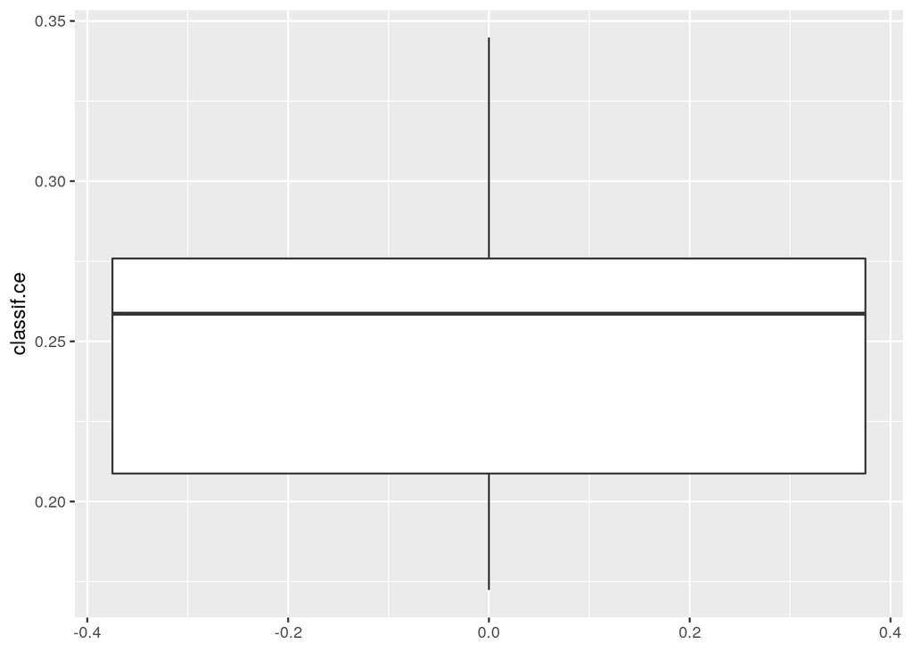

```r
autoplot(rr)
```

W przypadku błędów kroswalidacji przeprowadzonej na powyższym zbiorze, mediana błędu wynosi ok 0.26, przy czym rozrzut wszystkich wyników, przy umiarkowanym rozstępie międzykwartylowym, jest znaczny. W zależności od iteracji błąd wahał się w granicach 0.15 - 0.35.

**Średnia dokładność kroswalidacji**

```r
rr$aggregate(msr("classif.acc"))
```

```
## classif.acc
##        0.75
```

**Dokładność klasyfikacji na zbiorze testowym**

```r
acc <- (conf2.val['TP']+conf2.val['TN'])/sum(conf2.val)
acc
```

```
##        TP
## 0.7586207
```

Błąd uzyskanu na zbiorze testowym (który nie był wykorzystywany w kroswalidacji) jest zbliżony do średniego błędu z kroswalidacji, zatem teoretycznie możemy uznać model za dobrze przygotowany.

### 4.2. Usunięcie kolumn zawierających braki danych

```r
dim(df_wo_na_cols)
```

```
## [1] 540   9
```

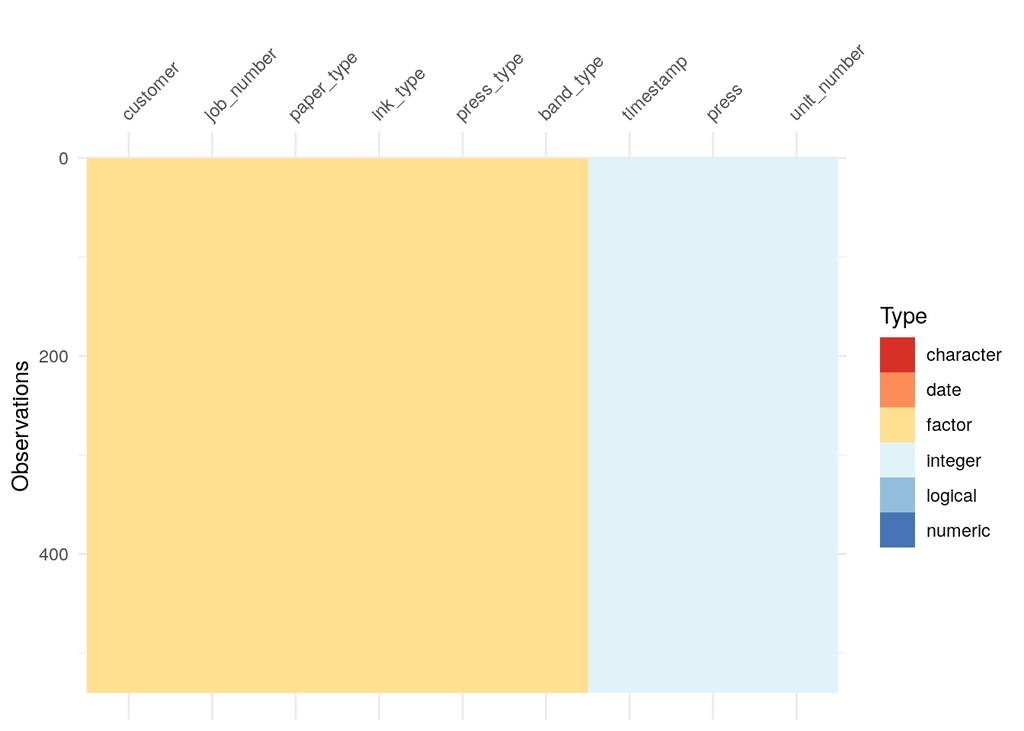

```r
# Brak braków
vis_dat(df_wo_na_cols, palette = 'cb_safe')
```

#### 4.2.1. Predykcja klasy - macierz błędu

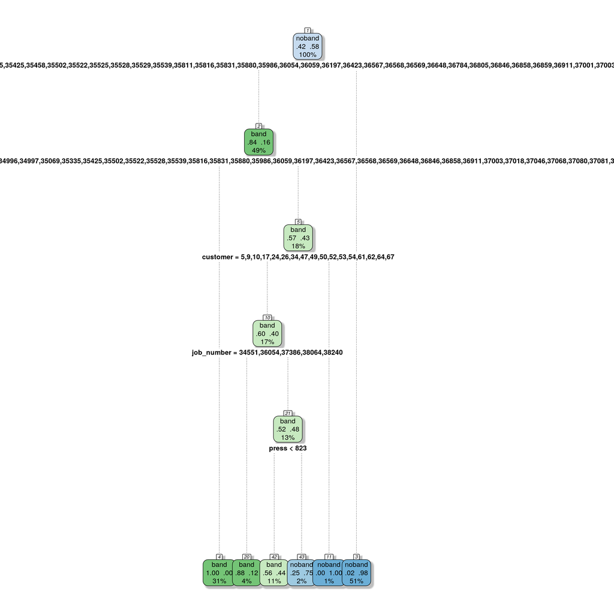

```r
tree_classifier <- rpart(band_type~., data=df_train)
fancyRpartPlot(tree_classifier_parameter_change, caption = NULL, cex = 1)
```

Struktury powyższego drzewa oraz otrzymanego w sekcji 4.1. różnią się - dla różnych metod imputacji tych samych danych otrzymujemy różne natury podziałów na klasy.

**Macierz błędu**

```r
table('Reference'= df_test$band_type, 'Prediction' = tree_classifier_test_prediction_class)
```

```
##          Prediction
## Reference PRED_BAND PRED_NOBAND
##    band          30          15
##    noband        14          49
```

**Dokładność (accuracy)**

```r
accuracy <- (conf.val['TP']+conf.val['TN'])/sum(conf.val)
accuracy
```

```
##        TP
## 0.7314815
```

#### 4.2.2. Predykcja prawdopodobieństwa

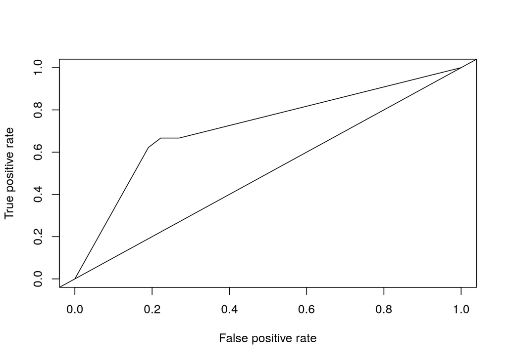

```r
plot(roc.perf)
abline(a=0, b= 1)
```

**Miara AUC**

```r
# Wykres nieco bardziej stromy niż w poprzednim przypadku -> teoretycznie mamy do czynienia z lepszą klasyfikacją.
auc.perf <- performance(pred, measure = "auc")
auc.perf@y.values
```

```
## [[1]]
## [1] 0.7199295
```

#### 4.2.3. Kroswalidacja

**Porównanie błędów z kroswalidacji**

```r
rr$score(msr("classif.acc"))
```

```
##              task       task_id               learner    learner_id
##  1: <TaskClassif> df_wo_na_cols <LearnerClassifRpart> classif.rpart
##  2: <TaskClassif> df_wo_na_cols <LearnerClassifRpart> classif.rpart
##  3: <TaskClassif> df_wo_na_cols <LearnerClassifRpart> classif.rpart
##  4: <TaskClassif> df_wo_na_cols <LearnerClassifRpart> classif.rpart
##  5: <TaskClassif> df_wo_na_cols <LearnerClassifRpart> classif.rpart
##  6: <TaskClassif> df_wo_na_cols <LearnerClassifRpart> classif.rpart
##  7: <TaskClassif> df_wo_na_cols <LearnerClassifRpart> classif.rpart
##  8: <TaskClassif> df_wo_na_cols <LearnerClassifRpart> classif.rpart
##  9: <TaskClassif> df_wo_na_cols <LearnerClassifRpart> classif.rpart
## 10: <TaskClassif> df_wo_na_cols <LearnerClassifRpart> classif.rpart
##         resampling resampling_id iteration prediction classif.acc
##  1: <ResamplingCV>            cv         1     <list>   0.7962963
##  2: <ResamplingCV>            cv         2     <list>   0.7592593
##  3: <ResamplingCV>            cv         3     <list>   0.7037037
##  4: <ResamplingCV>            cv         4     <list>   0.8518519
##  5: <ResamplingCV>            cv         5     <list>   0.7962963
##  6: <ResamplingCV>            cv         6     <list>   0.7037037
##  7: <ResamplingCV>            cv         7     <list>   0.6851852
##  8: <ResamplingCV>            cv         8     <list>   0.6666667
##  9: <ResamplingCV>            cv         9     <list>   0.8148148
## 10: <ResamplingCV>            cv        10     <list>   0.6851852
```

**Wizualizacja błędów z kroswalidacji**

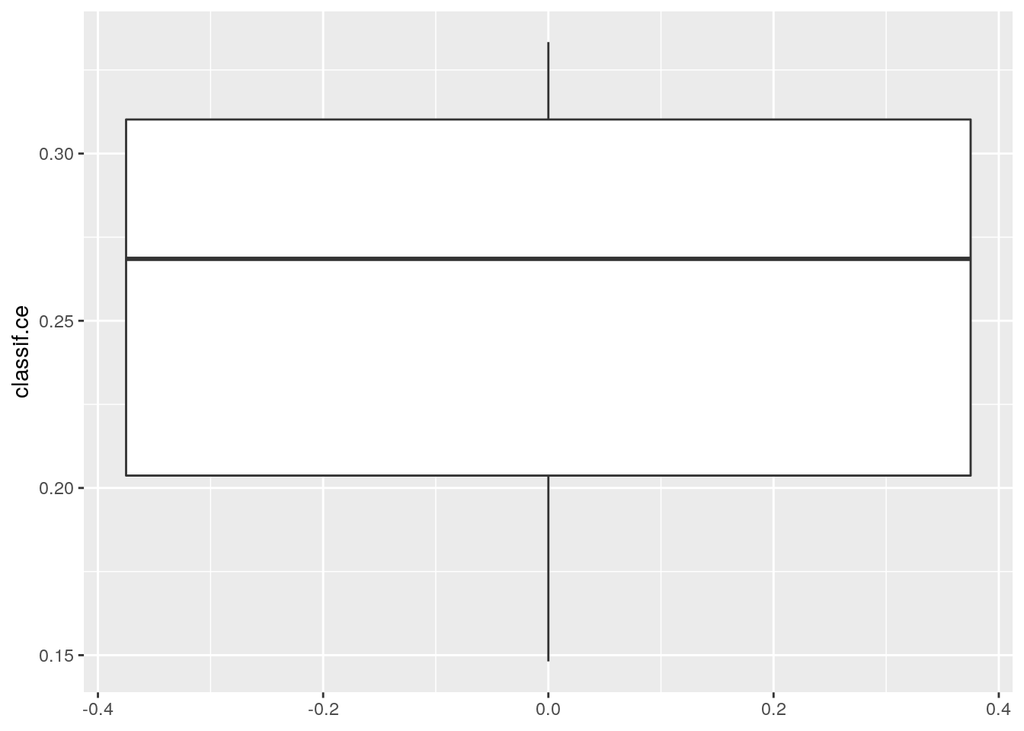

```r
autoplot(rr)
```

Wartości błędów klasyfikacji dla poszczególnych iteracji procesu kroswalidacji są mniej zbilansowane, algorytm działa w sposób mniej zrównoważony (większy rozstęp międzykwartylowy przy zachowanym rozrzucie wszystkich danych).

**Średni błąd z kroswalidacji**

```r
rr$aggregate(msr("classif.acc"))
```

```
## classif.acc
##   0.7462963
```

**Dokładność klasyfikacji na zbiorze testowym**

```r
acc <- (conf2.val['TP']+conf2.val['TN'])/sum(conf2.val)
acc
```

```
##        TP
## 0.6944444
```

Błąd uzyskanu na zbiorze testowym (który nie był wykorzystywany w kroswalidacji) jest nie jest aż tak wyraźnie zbliżony do średniego błędu z kroswalidacji jak w poprzednich przypadkach.

### 4.3. Zastąpienie brakujących danych dominantami poszczególnych kolumn

```r
vis_dat(df_with_modes, palette = 'cb_safe')
```

[output not shown]

#### 4.3.1. Predykcja klasy

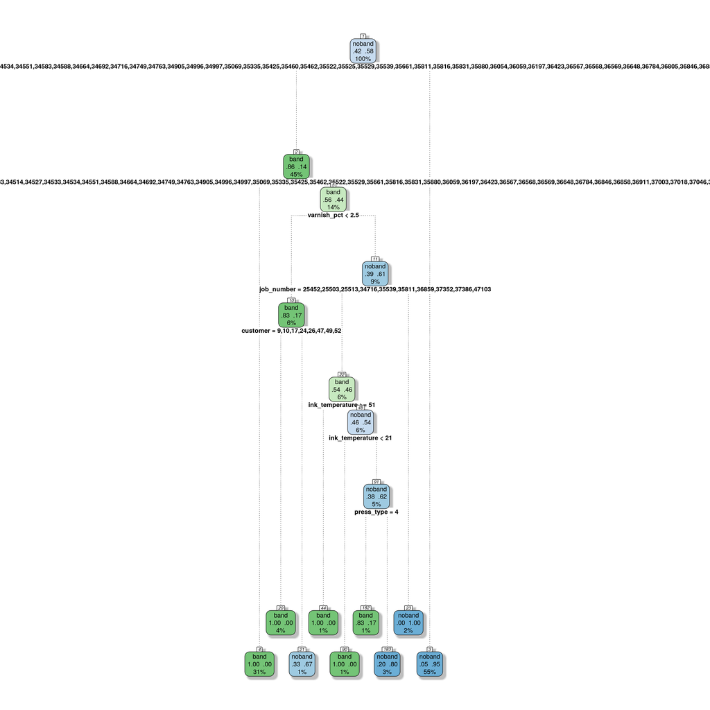

```r
tree_classifier <- rpart(band_type~., data=df_train)
fancyRpartPlot(tree_classifier_parameter_change, caption = NULL, cex = 0.8)
```

Znów, warto zwrócić uwagę, że dla każdej metody imputacji, drzewo klasyfikacyjne wygląda inaczej.

**Macierz błędu**

```r
table('Reference'= df_test$band_type, 'Prediction' = tree_classifier_test_prediction_class)
```

```
##          Prediction
## Reference PRED_BAND PRED_NOBAND
##    band          27          21
##    noband        12          48
```

**Dokładność (accuracy)**

```r
accuracy <- (conf.val['TP']+conf.val['TN'])/sum(conf.val)
accuracy
```

```
##        TP
## 0.6944444
```

#### 4.3.2. Predykcja prawdopodobieństwa

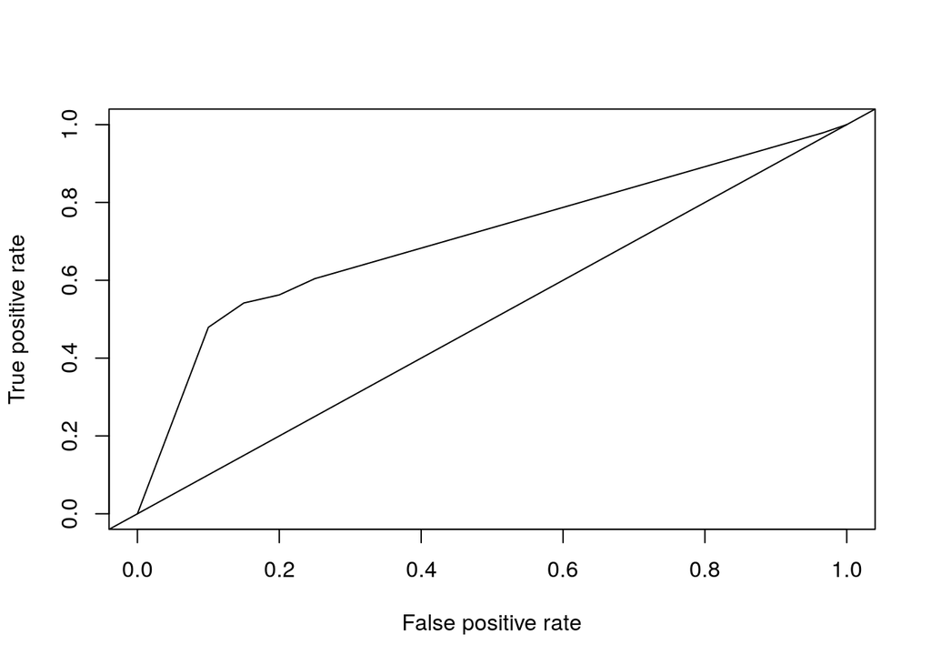

```r
plot(roc.perf)
abline(a=0, b= 1)
```

**Miara AUC**

```r
auc.perf <- performance(pred, measure = "auc")
auc.perf@y.values
```

```
## [[1]]
## [1] 0.7065972
```

Wartości rozważanych miar są zbliżone do uzyskanych w pierwszej z rozważanych z technik (usunięcie wierszy), ale gorsze niż w przypadku usunięcia kolumn.

#### 4.3.3. Kroswalidacja

**Porównanie błędów z kroswalidacji**

```r
rr$score(msr("classif.acc"))
```

```
##              task       task_id               learner    learner_id
##  1: <TaskClassif> df_with_modes <LearnerClassifRpart> classif.rpart
##  2: <TaskClassif> df_with_modes <LearnerClassifRpart> classif.rpart
##  3: <TaskClassif> df_with_modes <LearnerClassifRpart> classif.rpart
##  4: <TaskClassif> df_with_modes <LearnerClassifRpart> classif.rpart
##  5: <TaskClassif> df_with_modes <LearnerClassifRpart> classif.rpart
##  6: <TaskClassif> df_with_modes <LearnerClassifRpart> classif.rpart
##  7: <TaskClassif> df_with_modes <LearnerClassifRpart> classif.rpart
##  8: <TaskClassif> df_with_modes <LearnerClassifRpart> classif.rpart
##  9: <TaskClassif> df_with_modes <LearnerClassifRpart> classif.rpart
## 10: <TaskClassif> df_with_modes <LearnerClassifRpart> classif.rpart
##         resampling resampling_id iteration prediction classif.acc
##  1: <ResamplingCV>            cv         1     <list>   0.7962963
##  2: <ResamplingCV>            cv         2     <list>   0.7592593
##  3: <ResamplingCV>            cv         3     <list>   0.7037037
##  4: <ResamplingCV>            cv         4     <list>   0.7222222
##  5: <ResamplingCV>            cv         5     <list>   0.7407407
##  6: <ResamplingCV>            cv         6     <list>   0.6666667
##  7: <ResamplingCV>            cv         7     <list>   0.8333333
##  8: <ResamplingCV>            cv         8     <list>   0.6851852
##  9: <ResamplingCV>            cv         9     <list>   0.7962963
## 10: <ResamplingCV>            cv        10     <list>   0.8148148
```

**Wizualizacja błędów z kroswalidacji**

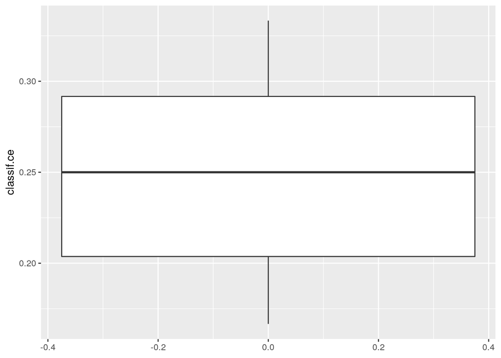

```r
autoplot(rr)
```

Wartości błędów klasyfikacji dla poszczególnych iteracji procesu kroswalidacji są względnie zbilansowane. Zrównoważenie działania algorytmu jest zbliżone do poprzednich przypadków (choć nieco lepsze). Wartości charakterystyk położenia jest korzystniejsze niż w powyżej.

**Średni błąd z kroswalidacji**

```r
rr$aggregate(msr("classif.acc"))
```

```
## classif.acc
##   0.7518519
```

**Dokładność klasyfikacji na zbiorze testowym**

```r
acc <- (conf2.val['TP']+conf2.val['TN'])/sum(conf2.val)
acc
```

```
##        TP
## 0.7685185
```

Błąd uzyskanu na zbiorze testowym (który nie był wykorzystywany w kroswalidacji) jest zbliżony do średniego błędu z kroswalidacji, zatem teoretycznie możemy uznać model za dobrze przygotowany.

### 4.4. Zastąpienie brakujących danych wartościami wylosowanymi z poszczególnych kolumn (random uniform)

```r
vis_dat(df_uniform_sampling, palette = 'cb_safe')
```

[output not shown]

#### 4.4.1. Predykcja klasy

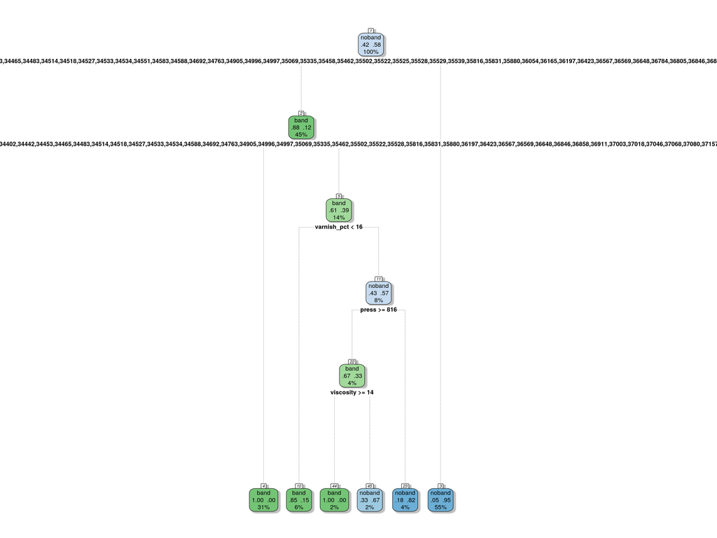

```r
tree_classifier <- rpart(band_type~., data=df_train)
fancyRpartPlot(tree_classifier_parameter_change, caption = NULL, cex = 1)
```

**Macierz błędu**

```r
table('Reference'= df_test$band_type, 'Prediction' = tree_classifier_test_prediction_class)
```

```
##          Prediction
## Reference PRED_BAND PRED_NOBAND
##    band          25          20
##    noband         6          57
```

**Dokładność (accuracy)**

```r
accuracy <- (conf.val['TP']+conf.val['TN'])/sum(conf.val)
accuracy
```

```
##        TP
## 0.7592593
```

Najwyższa dokładność w porównaniu z pozostałymi technikami.

#### 4.4.2. Predykcja prawdopodobieństwa

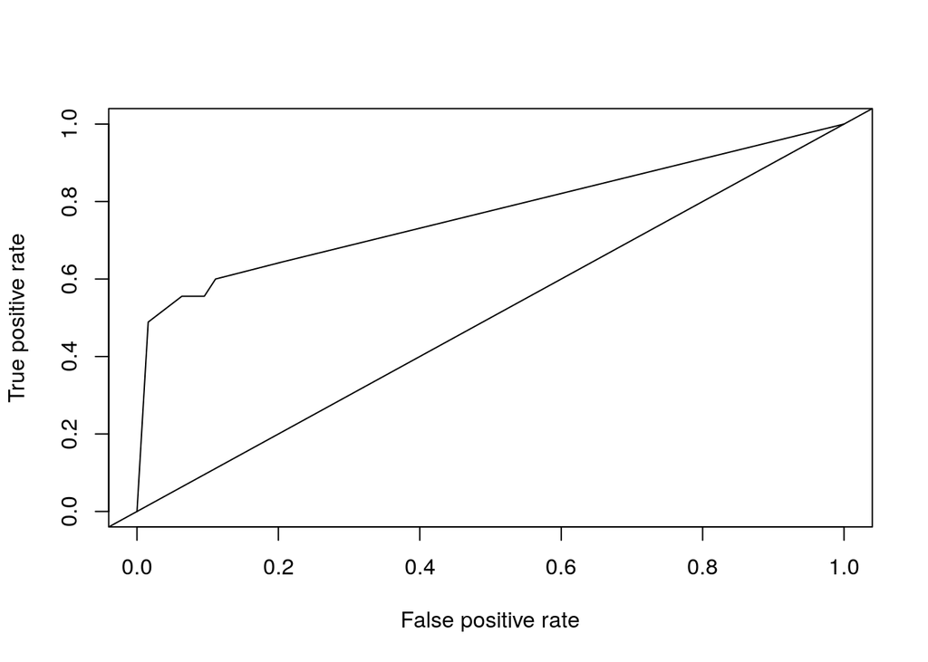

```r
plot(roc.perf)
abline(a=0, b= 1)
```

Najbardziej stroma prosta ze wszystkich rozważanych!

**Miara AUC**

```r
auc.perf <- performance(pred, measure = "auc")
auc.perf@y.values
```

```
## [[1]]
## [1] 0.7673721
```

#### 4.4.3. Kroswalidacja

**Porównanie błędów z kroswalidacji**

```r
rr$score(msr("classif.acc"))
```

```
##              task             task_id               learner    learner_id
##  1: <TaskClassif> df_uniform_sampling <LearnerClassifRpart> classif.rpart
##  2: <TaskClassif> df_uniform_sampling <LearnerClassifRpart> classif.rpart
##  3: <TaskClassif> df_uniform_sampling <LearnerClassifRpart> classif.rpart
##  4: <TaskClassif> df_uniform_sampling <LearnerClassifRpart> classif.rpart
##  5: <TaskClassif> df_uniform_sampling <LearnerClassifRpart> classif.rpart
##  6: <TaskClassif> df_uniform_sampling <LearnerClassifRpart> classif.rpart
##  7: <TaskClassif> df_uniform_sampling <LearnerClassifRpart> classif.rpart
##  8: <TaskClassif> df_uniform_sampling <LearnerClassifRpart> classif.rpart
##  9: <TaskClassif> df_uniform_sampling <LearnerClassifRpart> classif.rpart
## 10: <TaskClassif> df_uniform_sampling <LearnerClassifRpart> classif.rpart
##         resampling resampling_id iteration prediction classif.acc
##  1: <ResamplingCV>            cv         1     <list>   0.7592593
##  2: <ResamplingCV>            cv         2     <list>   0.7037037
##  3: <ResamplingCV>            cv         3     <list>   0.7407407
##  4: <ResamplingCV>            cv         4     <list>   0.7037037
##  5: <ResamplingCV>            cv         5     <list>   0.7407407
##  6: <ResamplingCV>            cv         6     <list>   0.6851852
##  7: <ResamplingCV>            cv         7     <list>   0.6851852
##  8: <ResamplingCV>            cv         8     <list>   0.5925926
##  9: <ResamplingCV>            cv         9     <list>   0.6851852
## 10: <ResamplingCV>            cv        10     <list>   0.7037037
```

**Wizualizacja błędów z kroswalidacji**

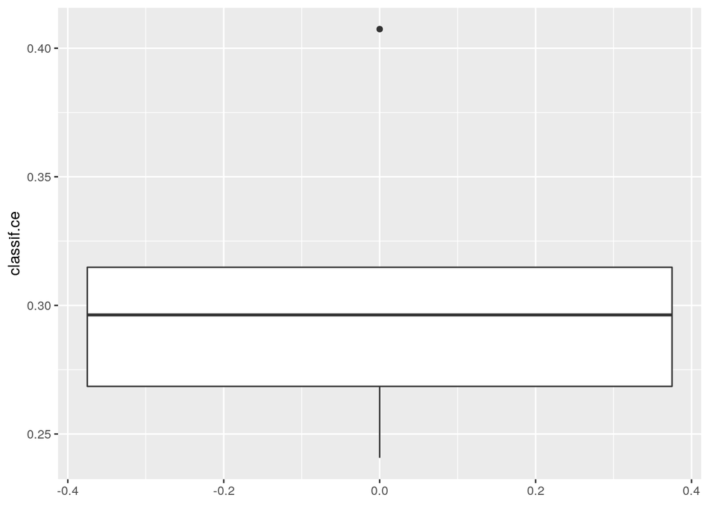

```r
autoplot(rr)
```

Najbardziej zrównoważony algorytm w porównaniu z rozważanym wcześnie, ale jednocześnie najgorsze wartości charakterystyk. Położenie punktu odstającego wskazuje, że w jednej z iteracji ponad 40% obserwacji została zaklasyfikowana do niewłaściwych kategorii!

**Średni błąd z kroswalidacji**

```r
rr$aggregate(msr("classif.acc"))
```

[output not shown]

**Dokładność klasyfikacji na zbiorze testowym**

```r
acc <- (conf2.val['TP']+conf2.val['TN'])/sum(conf2.val)
acc
```

```
##        TP
## 0.6759259
```

Błąd uzyskanu na zbiorze testowym (który nie był wykorzystywany w kroswalidacji) jest nie jest aż tak wyraźnie zbliżony do średniego błędu z kroswalidacji jak w poprzednich przypadkach.